# Trump’s Tweets Exploration

Shira Wild, Maayan Aviram and Noa Radin

First, let’s load the dataset and convert the dataset columns

```r
trumps_tweets <- readRDS(here::here("data", "trump_tweets.rds"))
```

Let’s take a look at the `trumps_tweets` dataset

```r
glimpse(trumps_tweets)
```

```
## Rows: 1,549
## Columns: 7
## $ Date      <date> 2020-04-04, 2020-04-04, 2020-04-04, 2020-04-04, 2020-04-04,~
## $ Favorites <dbl> 0, 74661, 0, 0, 0, 0, 0, 0, 32032, 0, 0, 0, 0, 0, 0, 0, 0, 0~
## $ Id        <chr> "1246434545357987842", "1246434478744047616", "1246434186942~
## $ isRetweet <lgl> TRUE, FALSE, TRUE, TRUE, TRUE, TRUE, TRUE, TRUE, FALSE, TRUE~
## $ Retweets  <dbl> 4410, 10449, 3063, 3321, 2500, 108116, 4579, 1938, 6306, 363~
## $ Text      <chr> "RT @IvankaTrump: Great reconnecting with President Kaljulai~
## $ Time      <chr> "16:48:47", "16:48:32", "16:47:22", "16:46:39", "16:46:31", ~
```

| Feature | Type | Description |
| --- | --- | --- |
| **Date** | Date | Represent the date of the tweet |
| **Favorites** | Double | The number of users marked the tweet as favorites |
| **Id** | Character | The id of the tweet |
| **isRetweet** | Boolean | Mark if the tweet is a retweet or not |
| **Retweets** | Double | The number of retweets on this tweet |
| **Text** | Character | The tweet’s content |
| **Time** | Character | The publish time of the tweet |

Let’s see the amount of tweets during the `Weekend`/`Weekdays`

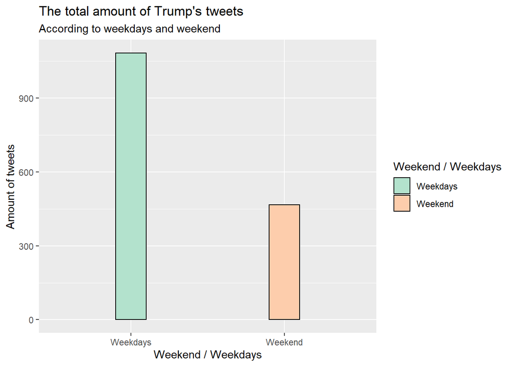

```r
Tweets_with_day <- trumps_tweets

# Add a column with the day of the week for each date
Tweets_with_day$day_of_week <- wday(trumps_tweets$Date, label = TRUE)

# Add a column that classify the day to weekend of weekdays
Tweets_with_day <- Tweets_with_day %>%
  mutate(Weekend = if_else(day_of_week %in% c("Sat", "Sun"), "Weekend", "Weekdays"))

# Plot the graph
ggplot(Tweets_with_day, aes(x = Weekend, position = "dodge", fill = Weekend)) +
    geom_bar(position = "dodge", width = 0.2, color="black") +
  scale_fill_brewer(palette="Pastel2") +
    labs(title = "The total amount of Trump's tweets", subtitle = "According to weekdays and weekend" , x = "Weekend / Weekdays", y = "Amount of tweets",fill = "Weekend / Weekdays")
```

We can see that there is a significant difference in the amount of tweets during the `weekdays` comparing to the amount of tweets during the `weekend`. We can observe that Trump posted more tweets during the weekdays than the weekend.

Now let’s see the distribution of posting tweets during the day according to `Weekend`/`Weekdays`

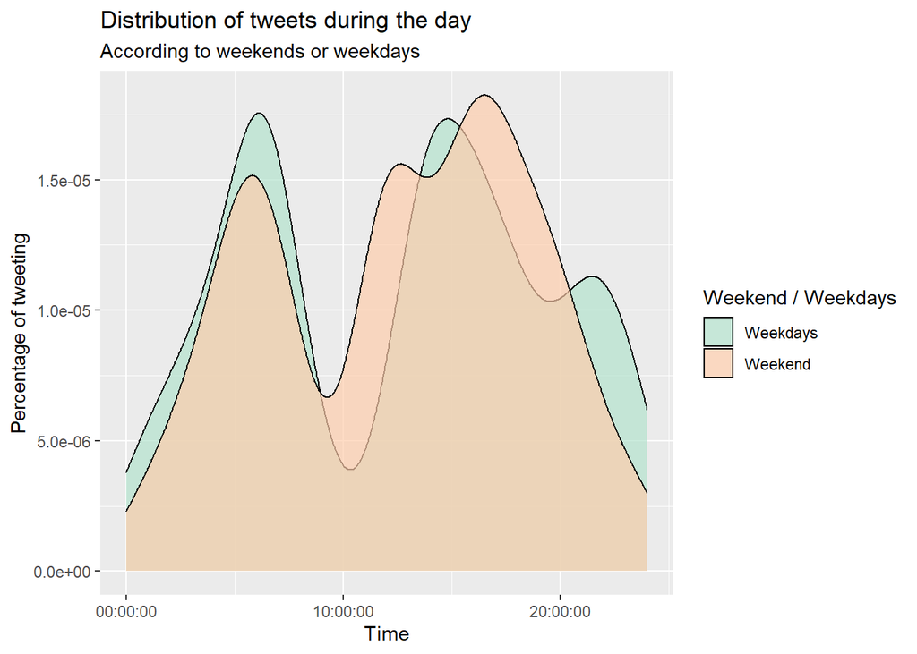

```r
# Plot the graph
ggplot(data = Tweets_with_day,
       mapping = aes(x = as_hms(Time),fill = Weekend)) +
  geom_density(alpha = 0.7, position = position_dodge(width=0.9))+
  scale_fill_brewer(palette="Pastel2")+
  labs(x= "Time", y= "Percentage of tweeting", title="Distribution of tweets during the day",
  subtitle = "According to weekends or weekdays",fill = "Weekend / Weekdays")
```

Now let’s compare the relationship between the number of retweets to the number of favorites

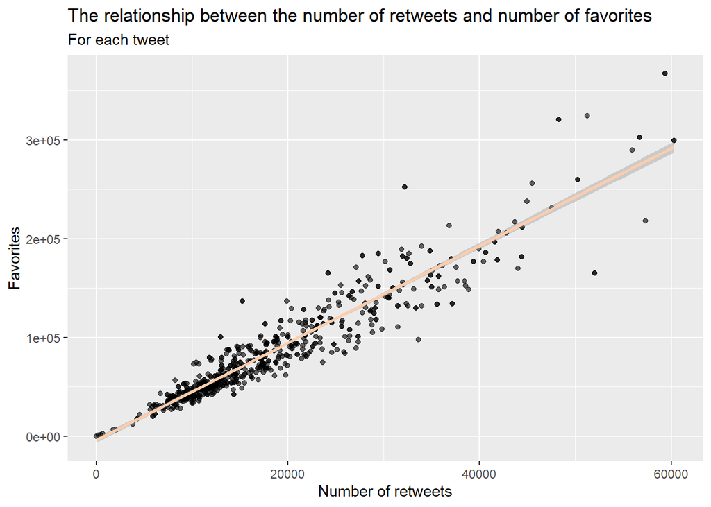

```r
# Filter the data. If tweet is a retweet the user cannot mark the tweet as favorite
only_retweeted <- filter(trumps_tweets, isRetweet==0)

# Clean the noisy data
only_retweeted_filtered <- filter(only_retweeted, Retweets<=60500)

# Plot the graph
ggplot(only_retweeted_filtered,
mapping = aes(x = Retweets, y = Favorites)) +
geom_point(alpha=0.6) +
geom_smooth(method = "lm",color = "#FDCDAC")+
labs(title = "The relationship between the number of retweets and number of favorites",subtitle = "For each tweet",  x = "Number of retweets", y = "Favorites")
```

This plot explores the connection between the number of retweets and the number of favorites for the different tweets. We can see that there is a clear connection between them. As the amount of retweets increases so does the amount of favorite markings on the tweets. This evidence makes sense, the amount of retweets on a tweet might indicates the degree of popularity of this tweet, Same with the amount of favorites for a tweet. Therefore, it’s logical that the `Favorites` and `Retweets` variables increase/decrease together.

Now let’s compare the histogram of Trump’s original tweets, and Trump’s Retweets (to other users)

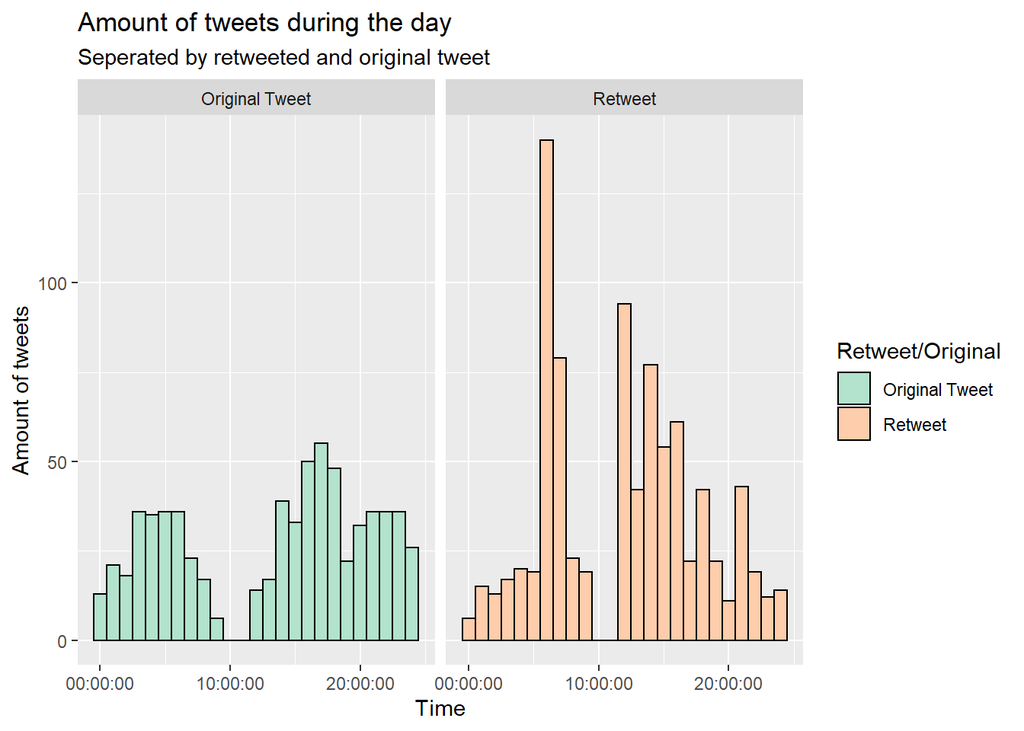

```r
#The histogram of tweets during the day

# Add a column that classify if the tweet is retweet or not
trumps_tweets <- trumps_tweets %>%
  mutate(Retweet = if_else(isRetweet == TRUE, "Retweet", "Original Tweet"))

ggplot(trumps_tweets, aes(x =as_hms(Time), fill = as.factor(Retweet)))+
    geom_histogram(bins = 25,  position = "dodge",color="black") +
  scale_fill_brewer(palette="Pastel2")+
  scale_color_brewer(palette="Pastel2")+
    facet_grid(~Retweet) +labs(x= "Time", y = "Amount of tweets", title = "Amount of tweets during the day" ,
  subtitle = "Seperated by retweeted and original tweet", fill = "Retweet/Original")
```

These distributions are not similar, We can observe that Trump is tending to tweet more retweets than original tweets. In addition to that we can see that in the `Retweet` histogram there are “peak hours” and in the `Original Tweet` histogram most of the day the amount of tweets remains relatively similar.

Now, we would like to see the amount of Trump’s tweets during the given period

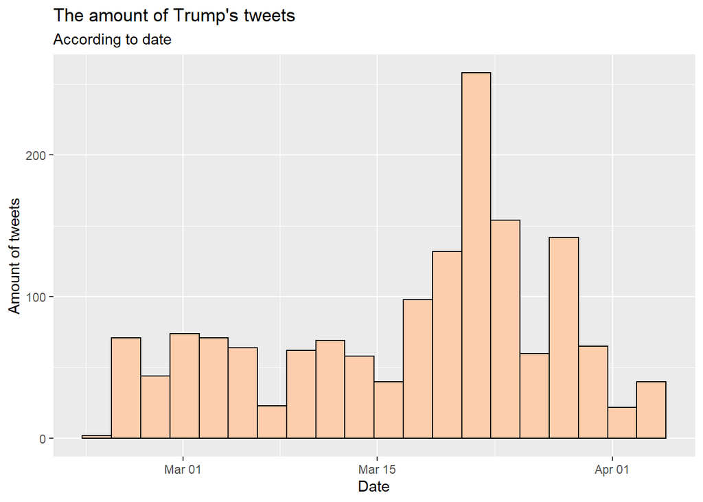

```r
ggplot(trumps_tweets, aes(x =Date))+
    geom_histogram(bins = 20,  position = "dodge",fill = "#FDCDAC",color="black") +
 labs(title = "The amount of Trump's tweets",subtitle = "According to date", x= "Date", y = "Amount of tweets")
```

Now, let’s observe the distribution of the number of words in each tweet Trump published

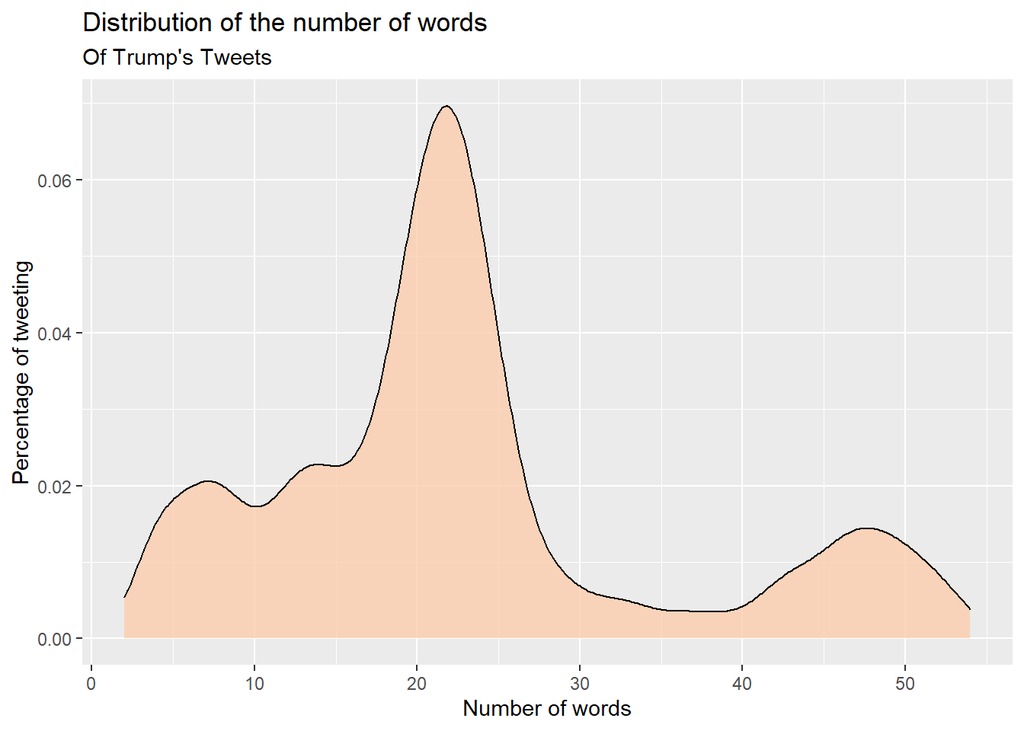

```r
# Create a column with the number of words in tweet
trumps_tweets <- trumps_tweets %>%
  mutate(n_words = trumps_tweets$Text %>% str_count("\\w+"))

ggplot(trumps_tweets, aes(x=n_words))+
  geom_density( fill = "#FDCDAC", alpha = 0.8) +
 labs(title = "Distribution of the number of words",
    subtitle = "Of Trump's Tweets",
    x = "Number of words",
    y = "Percentage of tweeting")
```